# 33-ENSO Complejo

Elio Campitelli

En el trabajo de PSA vi que los mapas de regresión de SST asociados a distintas fases del PSA muestran un ENSO con distintas localizaciones.

Figure 1: Mapas de regresión de PSA en sus distintas fase con sst (izquierda) y funcíon corriente en 200hPa (derecha).

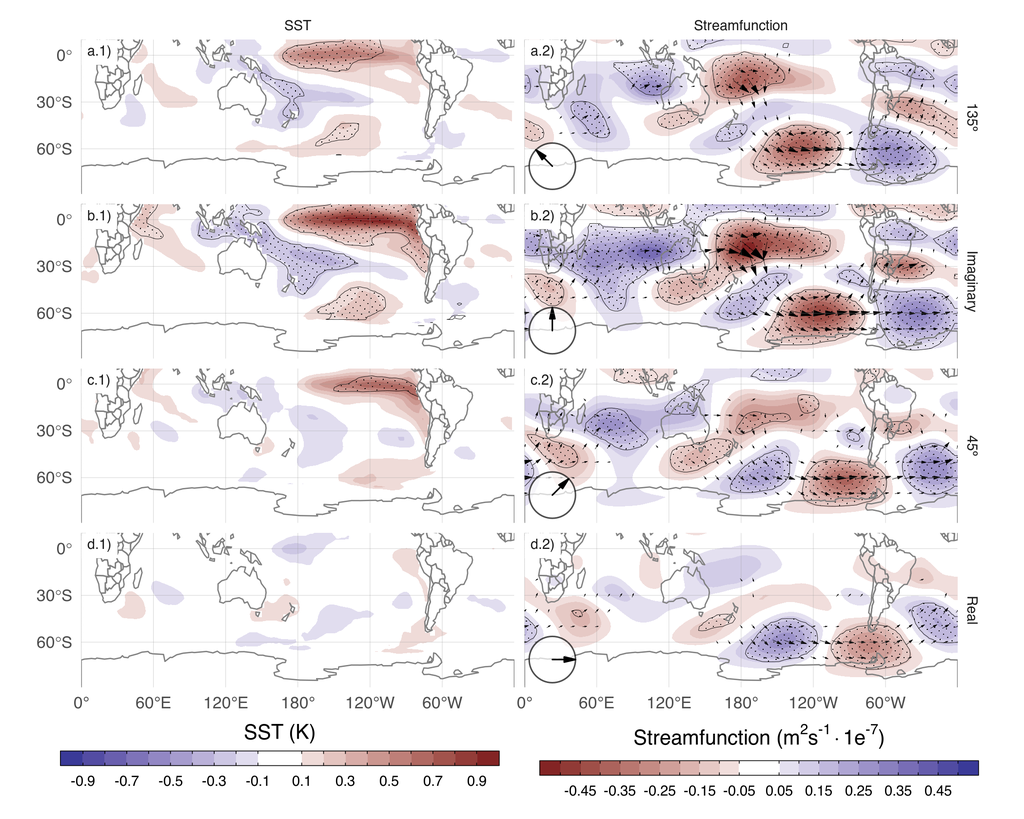

La pregunta ahora es si puedo ver la misma relación en reversa. Es decir, empezando con el ENSO en sus distintas localizaciones, ¿puedo ver un PSA con cambio de fase en los campos de regresión de la altura geopotencial?

Para eso voy a necesitar una forma de definir las localizaciones del ENSO. En la literatura están los índices de las “cajas” del ENSO (ENSO1+2, ENSO3, ENSO4, ENSO3.4) y también está el índice de El Niño Modoki. Algunos papers usan una definición de ENSO Central Pacific y Eastern Pacific a partir de las primeras dos componentes principales.

Yo voy a hacer algo parecido a esto último, pero dado que lo que estoy buscando es esencialmente una onda que cambia de fase, voy a usar EOF complejos nuevamente.

Lo que voy a hacer es calcular el EOF complejo de la SST promediada entre 5ºS y 5ºN. Un problema es que no tengo valores sobre los continentes así que voy a rellenar con una interpolación constante. Los valores imputados son un sinsentido, pero no debería importar demasiado porque son siempre iguales.

[Extended Reconstructed Sea Surface Temperature](https://psl.noaa.gov/data/gridded/data.noaa.ersst.v5.html) entre 1979 y 2020.

Como estoy haciendo la transformada de Hilbert, está bueno que el domino sea periódico, por eso es que prefiero rellenar los continentes en vez de hacer el EOF sólo usando los datos del Pacífico.

Otra cosa que voy a hacer es rotar el EOF de manera que la parte real tenga la máxima correlación parcial con el índice ENSO 3.4.

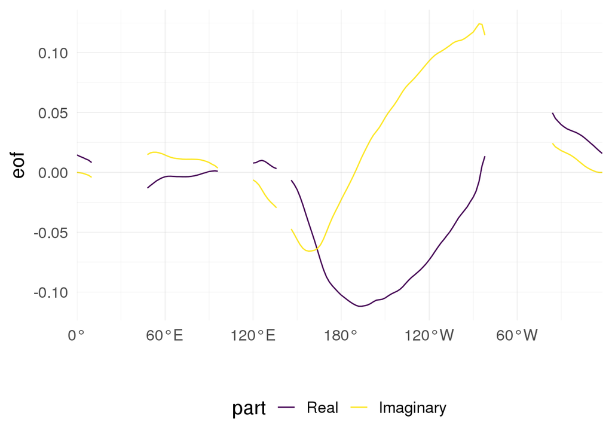

Figure 2: Primer EOF complejo de SST promediada entre 5ºS y 5ºN.

La Figura 2 muestra el patrón espacial del EOF complejo. Una posibilidad para calcular el índice temporal (extendiéndolo en el pasao) es proyectando este patrón pero sólo en la región del Pacífico. El problema de hacer esto es que, como no tienen media nula, los patrones son sensibles al calentamiento global. El patrón de la parte Real, por ejemplo, va a dar muy negativo en caso de Niño, pero tambień en caso de un aumento global en la temperatura de todo el océan.

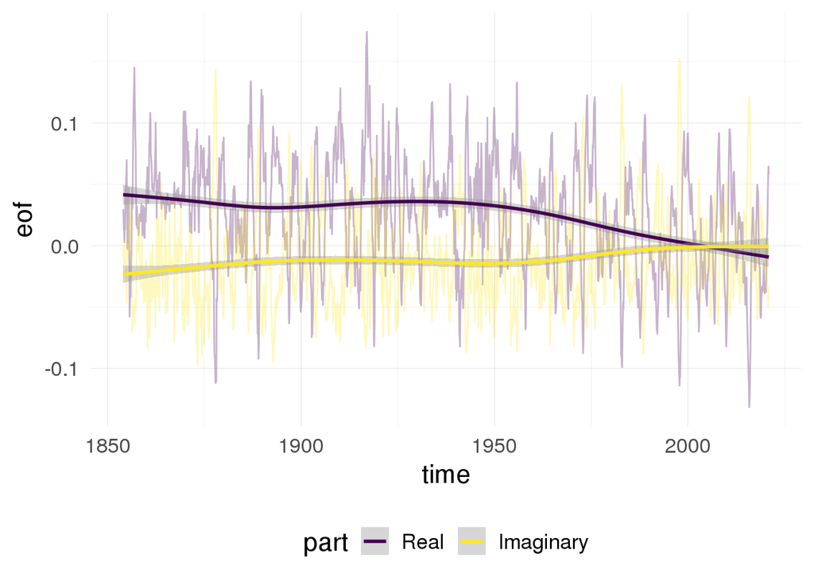

Figure 3: enso extendido

La proyección la voy a hacer con los datos de SST desde 1854, restándole la climatología de 1979 en adelante.

Figure 4: Regresión de SSTs con el EOF complejo.

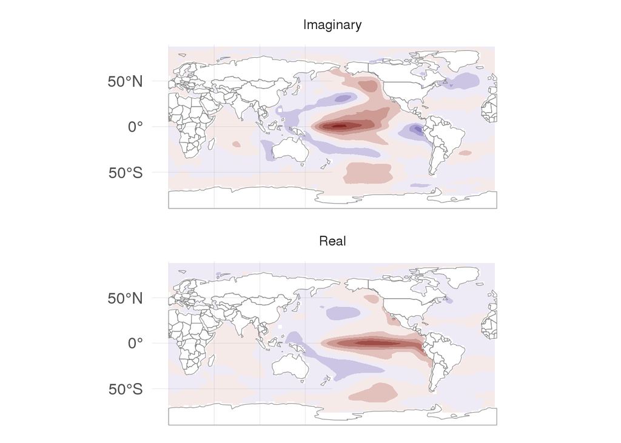

Figure 5: Valores del eof complejo en el eje horizontal vs. ENSO3.4 en el eje vertical. Muestra la alta correlación entre la parte real y el índice ENSO3.4"

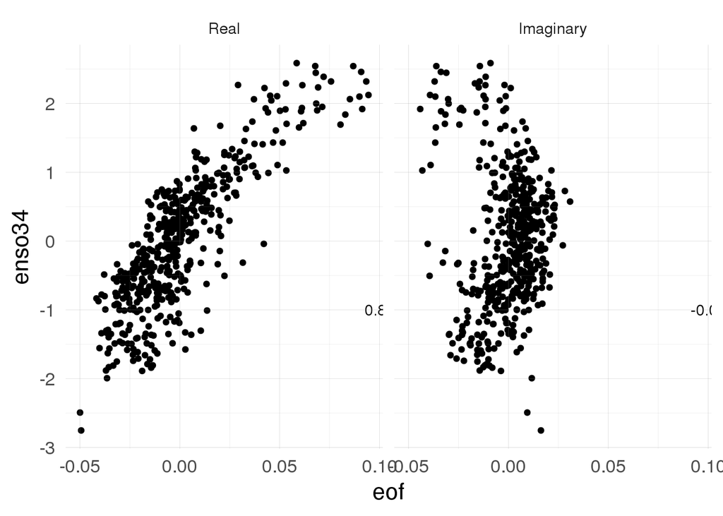

La Figura 5 muestra la relación entre el índice ENSO3.4 y las dos partes del EOF complejo. Hay una alta correlación entre el índice y la parte real, mientras que la correlación con la parte imaginaria es nula. Sin embargo, existe una clara relación no lineal entre la parte imaginaria y el ENSO34. Tanto valores altos como bajos (negativos) del índice están asociados a valores negativos de la parte imaginaria.

Figure 6: Relación entre la fase del eof (eje horizontal) y la magnitud (eje vertical derecho, puntos) e histograma que muestra la frecuencia observada de cada fase (barras, eje vertical izquierdo). En colores, la clasificación de eventos ENSO según el índice ENSO34 (+- 0.5).

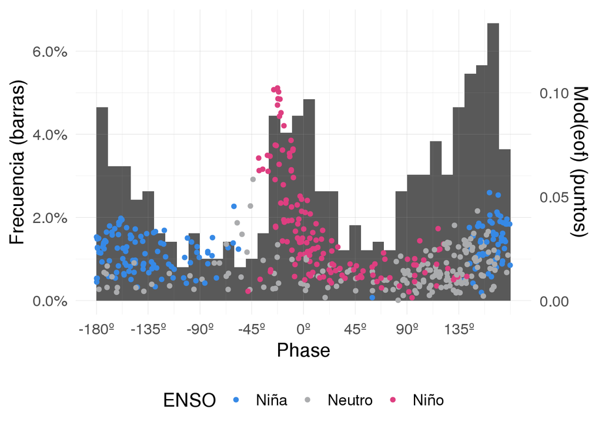

La Figura 6 muestra un histograma de la fase del EOF, mostrando que las fases más comunes son las cercanas a 0 (Real positivo, Niño) y 180 (Real negativo, Niña). Esto significa que la principal oscilación de ENSO es en el “eje” del ENSO canónico. El ENSO casi nunca se encuentra en la fase -90º (Imaginario negativo, indicando anomalías de SST corridas hacia el este) pero sí hay un poco más cerca de 90º (imaginario positivo, indicando anomalías de SST corridas hacia el oeste).

La Figura 6 también muestra, en puntos, la magnitud y fase observadas en cada mes, junto con el tipo de evento ENSO categorizado como $\pm0.5$ ENSO3.4. Esto muestra que no sólo las fases cercanas al ENSO canónico son las más comunes, sino que también son las asociadas con magnitudes más altas.

En resumen,

- el ENSO suele alinearse en el eje del ENSO canónio con mayor frecuencia,
- el ENSO es más intenso (tanto positivo como negativo) cuando se alínea con el ENSO canónico,
- los desvíos significativos con respecto al ENSO canónico se dan únicamente en la dirección del centro de anomalías positivas corrido hacia el oeste.

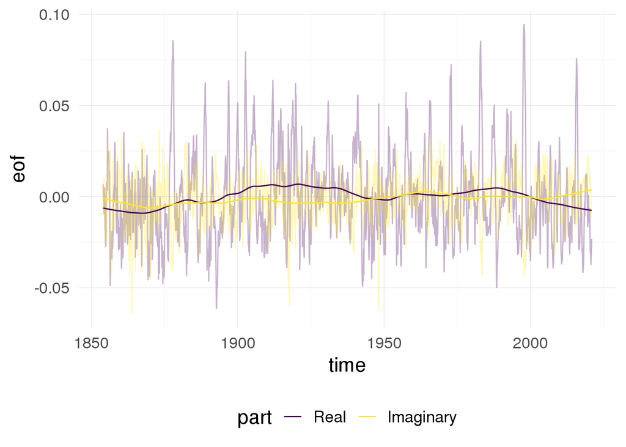

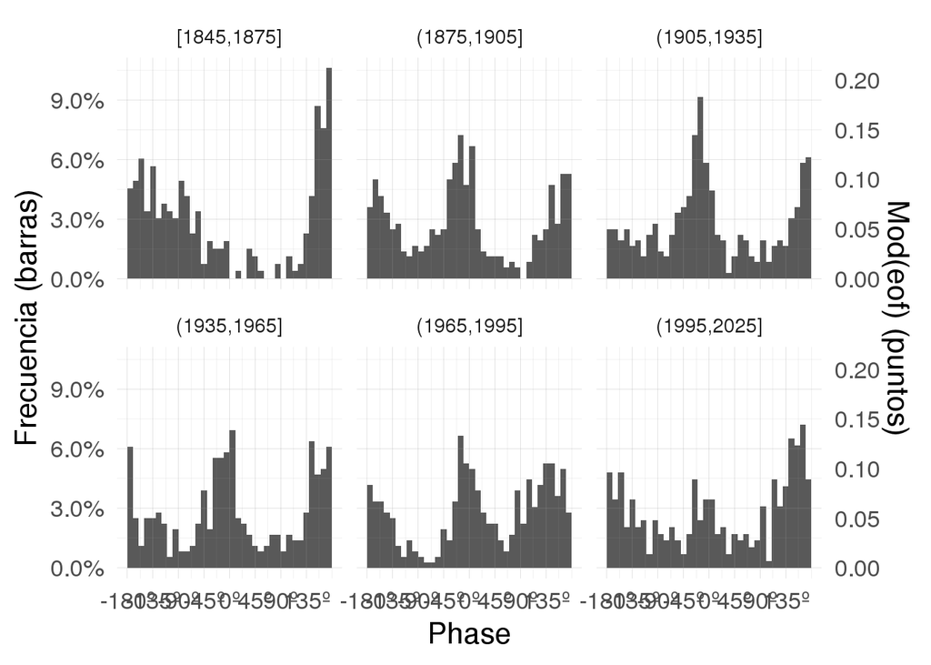